# Analysis OF WeRateDogs Twitter Archive

WeRateDogs is a Twitter account that rates people's dogs with a humorous comment about the dog. I gathered data on WeRateDogs twitter archive from different sources; their Twitter archive that was downloaded manually, and extra tweet information using Twitter API. I also had access to an image prediction data. Using Python libraries, I assessed the different data for quality and tidiness issues and cleaned all the issues I identified, so as to obtain data that can easily be used for analysis and visualizations. After wrangling, I was able to analyze the data and I got the following insights:

### Dog stage with highest average rating

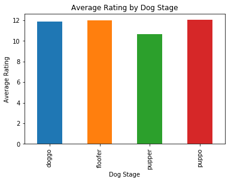

### Average favorite and retweet counts per dog stage

Once again, Puppo topped the list with an average of 7,027 retweets and 22,724 likes. Doggo got the next highest number likes and retweets. Floofer comes next and Pupper received the least number of reaction on average.

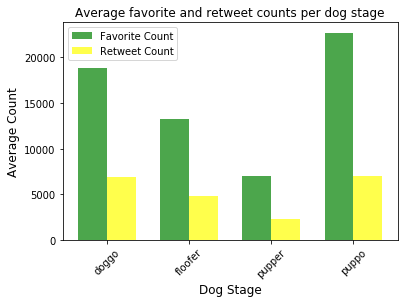

### Most common breeds that the model predicted with the highest confidence

The model was most confident in predicting Golden Retrievers the most number of times with an average confidence level of 71.99%. However, on average, the model predicted Komondors with the highest confidence level, this might be because there are only 3 Komondor predictions.

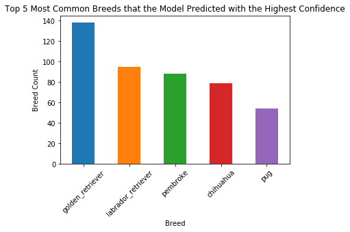

### Most common tweet source

IPhones were used the most to post rating( Twitter for iPhone), then web(Twitter Web Client), with TweetDeck being used the least number of times. 98.1% of tweets were tweeted from an iPhone, 1.4% from Twitter Web Client and 0.5% from TweetDeck. This also shows that the only mobile device used by WeRateDogs to tweet is iPhone.

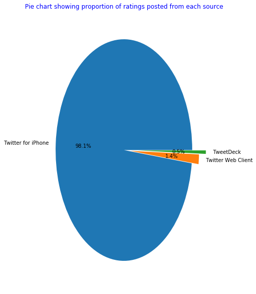

### Distribution of WeRateDogs Tweets over Time

WeRateDogs Twitter archive shows a tremendous decrease in the number of tweets posted from 2015 to 2017, going from an average of 331 tweets per month in 2015, to less than 50 tweets per month in 2017.

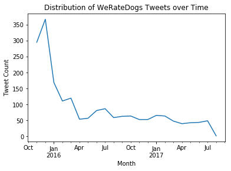

### Number of Tweets made per Day of Week

Based on the Twitter archive, we can say that Monday is the WeRateDogs favorite posting day.

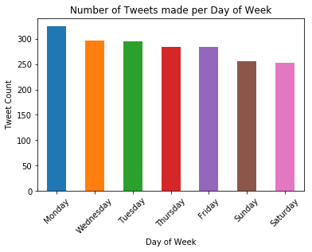